# CFRM 502, Winter 2020

# Instructor: Bahman Angoshtari

# Lecture 3

**Chapter 9:** analysis of variance (ANOVA), model selection (adj. R$^2$, AIC, and BIC)

$\newcommand\ee{\mathrm{e}}$ $\newcommand{\eps}{\varepsilon}$ $\newcommand{\Var}{\operatorname{Var}}$ $\newcommand\Cov{\operatorname{Cov}}$ $\newcommand{\sig}{\sigma}$ $\newcommand{\al}{\alpha}$ $\newcommand{\tht}{\theta}$ $\newcommand{\Xb}{\bar{X}}$ $\newcommand{\Yb}{\bar{Y}}$ $\newcommand\Eb{\mathbb{E}}$ $\newcommand\Pb{\mathbb{P}}$ $\newcommand\Qb{\mathbb{Q}}$ $\newcommand\Rb{\mathbb{R}}$ $\newcommand\Zb{\mathbb{Z}}$ $\newcommand\Nb{\mathbb{N}}$ $\newcommand\Av{\textbf{A}}$ $\newcommand\Fv{\textbf{F}}$ $\newcommand\Gv{\textbf{G}}$ $\newcommand\Hv{\textbf{H}}$ $\newcommand\Kv{\textbf{K}}$ $\newcommand\Iv{\textbf{I}}$ $\newcommand\Pv{\textbf{P}}$ $\newcommand\Sv{\textbf{S}}$ $\newcommand\Xv{\textbf{X}}$ $\newcommand\Yv{\textbf{Y}}$ $\newcommand\Zv{\textbf{Z}}$ $\newcommand\av{\mathbf{a}}$ $\newcommand\xv{\mathbf{x}}$ $\newcommand\yv{\mathbf{y}}$ $\newcommand\zv{\mathbf{z}}$ $\newcommand\Cv{\mathbf{C}}$ $\newcommand\mv{\mathbf{m}}$ $\newcommand\nv{\mathbf{n}}$ $\newcommand\pv{\mathbf{p}}$ $\newcommand\sv{\mathbf{s}}$ $\newcommand\wv{\mathbf{w}}$ $\newcommand\Wv{\textbf{W}}$ $\newcommand\betav{{\boldsymbol\beta}}$ $\newcommand\thtv{{\boldsymbol\tht}}$ $\newcommand\etav{{\boldsymbol\eta}}$ $\newcommand\epsv{{\boldsymbol\varepsilon}}$ $\newcommand\delv{{\boldsymbol\delta}}$ $\newcommand\Lamv{{\boldsymbol\Lambda}}$ $\newcommand\lamv{{\boldsymbol\lambda}}$ $\newcommand\muv{{\boldsymbol\mu}}$ $\newcommand\piv{{\boldsymbol\pi}}$ $\newcommand\Pbh{\widehat{\Pb}}$ $\newcommand\Ebh{\widehat{\Eb}}$ $\newcommand\Qh{\widehat{Q}}$ $\newcommand\Ih{\widehat{I}}$ $\newcommand\pih{\widehat{\pi}}$ $\newcommand\Pih{\widehat{\Pi}}$ $\newcommand\Wh{\widehat{W}}$ $\newcommand\Fh{\widehat{F}}$ $\newcommand\Yh{\widehat{Y}}$ $\newcommand\Yvh{\widehat{\Yv}}$ $\newcommand\Ah{\widehat{\Ac}}$ $\newcommand\uh{\widehat{u}}$ $\newcommand\vh{\widehat{v}}$ $\newcommand\fh{\widehat{f}}$ $\newcommand\hh{\widehat{h}}$ $\newcommand\Bh{\widehat{B}}$ $\newcommand\rhoh{\widehat{\rho}}$ $\newcommand\nuh{\widehat{\nu}}$ $\newcommand\varphih{\widehat{\varphi}}$ $\newcommand\thetah{\widehat{\theta}}$ $\newcommand\betah{\widehat{\beta}}$ $\newcommand\betavh{\widehat{\boldsymbol\beta}}$ $\newcommand\kaph{\widehat{\kappa}}$ $\newcommand\sigh{\widehat{\sigma}}$ $\newcommand\epsh{\widehat{\eps}}$ $\newcommand\epsvh{\widehat{\epsv}}$

# 1. Analysis of Variance (ANOVA)

- The ANOVA table provides additional information about how good a regression model is
- Idea: Let $\Yb = \frac{\sum_{n=1}^N Y_n}{N}$, and $\Yh_n = \betah_0+\sum_{k=1}^p \betah_k X_{n,k}$. Then, one can show:

  $\underbrace{\sum_{n=1}^N \left(Y_n - \Yb\right)^2}_\text{total SS} = \underbrace{\sum_{n=1}^N \left(Y_n - \Yh_i\right)^2}_\text{residual SS} + \underbrace{\sum_{n=1}^N \left(\Yh_n - \Yb\right)^2}_\text{regression SS}$

  Here, SS stands for sum of squares

$\underbrace{\sum_{n=1}^N \left(Y_n - \Yb\right)^2}_\text{total SS} = \underbrace{\sum_{n=1}^N \left(Y_n - \Yh_i\right)^2}_\text{residual SS} + \underbrace{\sum_{n=1}^N \left(\Yh_n - \Yb\right)^2}_\text{regression SS}$

- Total SS is the total variation in the response variable

  Regression SS is the variation that is explained by the model

  Residual SS is the variation that is not explained by the model
- R$^2$ statistic indicates the goodness-of-fit of a regression model

  $\text{R}^2 = \frac{\text{regression SS}}{\text{total SS}} = 1 - \frac{\text{residual SS}}{\text{total SS}}$
- It can be shown that R$^2$ is the **square** of the sample correlation between $\{Y_n\}_{n=1}^N$ and $\{\Yh_n\}_{n=1}^N$, that is

  $\text{R}^2 = \left(\frac{S_{Y\Yh}}{\sqrt{S_Y^2 S_\Yh^2}}\right)^2$
- Recall that $S^2_Y := \frac{\sum_{n=1}^N (Y_n-\Yb)^2}{N-1}$ is the sample variance, and $S_{Y\Yh} = \frac{\sum_{n=1}^N (Y_n - \Yb)(\Yh_n-\overline{\Yh})}{N-1}$ is the sample covariance
- **ANOVA table** provides a sequence of tests to investigate the predictive power of the explanatory variables
- Let Model$_0$, ..., Model$_p$ be the following regression models

  Model$_0: Y_n = \beta_0 + \eps_n$

  Model$_1: Y_n = \beta_0 + \beta_1 X_{n,1} + \eps_n$

  Model$_2: Y_n = \beta_0 + \beta_1 X_{n,1} + \beta_2 X_{n,2} + \eps_n$

  $\vdots$

  Model$_p: Y_n = \beta_0 + \beta_1 X_{n,1} + \dots + \beta_p X_{n,p} + \eps_n$
- Let $\text{SS}\left(\text{Model}_k| \text{Model}_{k-1}\right)$ be the difference

  $\qquad\quad\text{regression SS of Model}_k - \text{regression SS of Model}_{k-1}$
- Note that $\text{SS}\left(\text{Model}_k| \text{Model}_{k-1}\right)$ is the extra variation that is explained by $\text{Model}_k$ compared to $\text{Model}_{k-1}$
- The ANOVA table report $\text{SS}\left(\text{Model}_1| \text{Model}_{0}\right) = \text{regression SS of Model}_1$

  $\text{SS}\left(\text{Model}_2| \text{Model}_{1}\right)$

  $\text{SS}\left(\text{Model}_3| \text{Model}_{2}\right)$, ...

  $\text{SS}\left(\text{Model}_p| \text{Model}_{p-1}\right)$

  as well the residual SS of Model$_p$
- Let us illustrate with the government v.s. corporate rate example from the previous lecture

```r
library(quantmod)
getSymbols(c("WAAA","DGS10","DGS30", "FF"), src="FRED")
dat <- na.locf(merge(WAAA,DGS10,DGS30,FF))[index(WAAA)]["1977-02-16/1993-12-31"]
AAA_dif = diff(as.vector(dat[,"WAAA"]))
DGS10_dif = diff(as.vector(dat[,"DGS10"]))
DGS30_dif = diff(as.vector(dat[,"DGS30"]))
FF_dif = diff(as.vector(dat[,"FF"]))
```

[output not shown]

1. 'WAAA'

2. 'DGS10'

3. 'DGS30'

4. 'FF'

```r
fit <- lm(AAA_dif ~ DGS10_dif+DGS30_dif+FF_dif)
anova(fit)
```

A anova: 4 × 5

|  | Df <int> | Sum Sq <dbl> | Mean Sq <dbl> | F value <dbl> | Pr(>F) <dbl> |
| --- | --- | --- | --- | --- | --- |
| DGS10_dif | 1 | 3.9660212 | 3.96602124 | 340.759407 | 1.595198e-64 |
| DGS30_dif | 1 | 0.1064681 | 0.10646809 | 9.147707 | 2.562971e-03 |
| FF_dif | 1 | 0.7493709 | 0.74937090 | 64.385733 | 3.274095e-15 |
| Residuals | 876 | 10.1955648 | 0.01163877 | NA | NA |

- What does $\displaystyle\frac{10.1955648}{876}=0.01163877$ represents?

```r
sqrt(10.1955648 / 876)
```

0.107883143274284

- This is $\sigh_\eps^2$, the estimate of the variance of error $\sig_\eps^2$

## 1.1. Degrees of freedom (DF) in ANOVA

- There is a geometric interpretation of LS estimation
  - There are N degrees of freedom is a sample (# of observations)
  - Estimating each parameter reduces the DF by 1 (LS is projection into a sub-space)
- Each sum of square has a degree of freedom associated with it
  - Total SS has $N-1$ DF
  - Regression SS for a model with p predictors has $p$ DF
  - Residual SS for a model with p predictors has $N-p-1$ DF
- The ratio of a sum of squares to its DF is called the mean sum of squares

  MS $:=\displaystyle \frac{\text{SS}}{\text{DF}}$
- For example Residual MS := $\displaystyle\frac{\text{residual SS}}{N-p-1}$ which we have already introduced as $\sigh_\eps^2$. It is an unbiased estimator for $\sig^2_\eps$
- Other mean sum of squares are used for F-tests.
- Consider two models I and II such that Model I is a special case of Model II, denoted by Model I $\subset$ Model II
- For example, consider

\begin{align*} &\text{Model}_1: Y_n = \beta_0 + \beta_1 X_{n,1} + \eps_n\\ &\text{Model}_3: Y_n = \beta_0 + \beta_1 X_{n,1} + \beta_2 X_{n,2} + \beta_3 X_{n,3} +\eps_n \end{align*}

- Model$_1\subset$ Model$_3$, since Model$_1$ is a special case of Model$_3$ where $\beta_2=\beta_3=0$
- A general type of statistical tests is as follows. We assume that Model II is true. We want to test if Model I is true or false
- We consider the following hypotheses:

\begin{align*} \begin{cases} H_0: \text{Model I is true}\\H_1: \text{Model I is false (but Model II is true)} \end{cases} \end{align*}

- Let $p_I$ and $p_{II}$ be the number of parameters of Model$_I$ and Model$_{II}$, respectively
- To find a corresponding test statistic, we define:
  - SS(II|I) := regression SS of Model II - regression SS of Model I
  - DF(II|I) := $p_{II}-p_{I}$
  - MS(II|I) := $\displaystyle\frac{\text{SS(II|I)}}{\text{DF(II|I)}}$.
  - $\sigh_\eps^2$ := residual MS of Model II
- The test statistic for $H_0$ versus $H_1$ is

  $\displaystyle F := \frac{\text{MS(II$|$I)}}{\sigh^2_{\eps}}$
- Under $H_0$, $F$ has a F-distribution with DF(II$|$I) and $N-p_{II}-1$ degrees of freedom
- A typical regression summary includes the F-statistic (and p-value) of the test

$\begin{cases}H_0: \text{Model}_0,\\H_1: \text{Model}_p,\end{cases}\quad\text{or, equivalently,}\quad\begin{cases}H_0: \beta_0=\dots=\beta_p=0,\\H_1: \beta_i\ne0 \text{ for some }i\in\{0,\dots,p\}\end{cases}$

```r
summary(lm(AAA_dif ~ DGS10_dif+DGS30_dif+FF_dif))
```

```
Call:
lm(formula = AAA_dif ~ DGS10_dif + DGS30_dif + FF_dif)

Residuals:
     Min       1Q   Median       3Q      Max
-0.44083 -0.04746  0.00176  0.04788  0.61805

Coefficients:
              Estimate Std. Error t value Pr(>|t|)
(Intercept) -0.0005413  0.0036369  -0.149  0.88171
DGS10_dif    0.1298585  0.0627883   2.068  0.03891 *
DGS30_dif    0.2147151  0.0696579   3.082  0.00212 **
FF_dif       0.0676681  0.0084331   8.024 3.27e-15 ***
---
Signif. codes:  0 ‘***’ 0.001 ‘**’ 0.01 ‘*’ 0.05 ‘.’ 0.1 ‘ ’ 1

Residual standard error: 0.1079 on 876 degrees of freedom
Multiple R-squared:  0.3211,	Adjusted R-squared:  0.3188
F-statistic: 138.1 on 3 and 876 DF,  p-value: < 2.2e-16
```

- An ANOVA table includes the F-statistic (and p-value) of the tests

  $\begin{cases}H_0: \text{Model}_{k-1},\\H_1: \text{Model}_k,\end{cases}\quad\text{or, equivalently, in Model}_k\quad\begin{cases}H_0: \beta_k=0,\\H_1: \beta_{k}\ne0,\end{cases}$

  for all $k\in\{1,\dots,p\}$

```r
anova(lm(AAA_dif ~ DGS10_dif+DGS30_dif+FF_dif))
```

A anova: 4 × 5

|  | Df <int> | Sum Sq <dbl> | Mean Sq <dbl> | F value <dbl> | Pr(>F) <dbl> |
| --- | --- | --- | --- | --- | --- |
| DGS10_dif | 1 | 3.9660212 | 3.96602124 | 340.759407 | 1.595198e-64 |
| DGS30_dif | 1 | 0.1064681 | 0.10646809 | 9.147707 | 2.562971e-03 |
| FF_dif | 1 | 0.7493709 | 0.74937090 | 64.385733 | 3.274095e-15 |
| Residuals | 876 | 10.1955648 | 0.01163877 | NA | NA |

- We have seen two tests for $H_0:\beta_k=0$ v.s. $H_1:\beta_k\ne0$
- Namely, the t-test in the regression summary and the F-test in the ANOVA table. Are they equivalent, or different?
- They may be equivalent or different. We should pay attention to the alternative hypothesis.
- What is the alternative hypothesis in the t-test for `DGS30_dif`?
- In a model with all three predictors, we have $\beta_{DGS30}\ne0$. The t-test answer whether adding `DGS30_dif` to the other two predictors worths it or not.
- What is the alternative hypothesis in the F-test for `DGS30_dif`?
- In a model with only `DGS10_dif` and `DGS30_dif`, we have $\beta_{DGS30}\ne0$. This F-test answers whether adding `DGS30_dif` to `DGS10_dif` worths it or not. It is not the same as the t-test.
- Consider the t-test and F-test for variable `FF_dif`. Convince yourself that the two tests are equivalent (that is, they have the same null and alternative hypothesis).
- The order of predictors in the ANOVA table is important!
- Compare the following table with the one presented before

```r
anova(lm(AAA_dif ~ FF_dif + DGS30_dif+DGS10_dif))
```

A anova: 4 × 5

|  | Df <int> | Sum Sq <dbl> | Mean Sq <dbl> | F value <dbl> | Pr(>F) <dbl> |
| --- | --- | --- | --- | --- | --- |
| FF_dif | 1 | 0.93989306 | 0.93989306 | 80.75534 | 1.542323e-18 |
| DGS30_dif | 1 | 3.83218313 | 3.83218313 | 329.26008 | 1.033831e-62 |
| DGS10_dif | 1 | 0.04978403 | 0.04978403 | 4.27743 | 3.891472e-02 |
| Residuals | 876 | 10.19556478 | 0.01163877 | NA | NA |

- To simultaneously test that 2 coefficients are zero, use the following R code

```r
modelI = lm(AAA_dif ~ FF_dif)
modelII = lm(AAA_dif ~ FF_dif +DGS30_dif + DGS10_dif)
anova(modelI, modelII)
```

A anova: 2 × 6

| Res.Df <dbl> | RSS <dbl> | Df <dbl> | Sum of Sq <dbl> | F <dbl> | Pr(>F) <dbl> |
| --- | --- | --- | --- | --- | --- |
| 878 | 14.07753 | NA | NA | NA | NA |
| 876 | 10.19556 | 2 | 3.881967 | 166.7688 | 4.26116e-62 |

- What are we testing here?

```r
modelI = lm(AAA_dif ~ FF_dif +DGS30_dif + DGS10_dif -1)
modelII = lm(AAA_dif ~ FF_dif +DGS30_dif + DGS10_dif)
anova(modelI, modelII)
```

A anova: 2 × 6

| Res.Df <dbl> | RSS <dbl> | Df <dbl> | Sum of Sq <dbl> | F <dbl> | Pr(>F) <dbl> |
| --- | --- | --- | --- | --- | --- |
| 877 | 10.19582 | NA | NA | NA | NA |
| 876 | 10.19556 | 1 | 0.0002578416 | 0.02215368 | 0.8817133 |

- Note: include "-1" on the right side to remove the intercept in the regression equation

# 2. Model selection

- Q: Does including a predictor (or set of predictors) in a model worth it? Which predictors to include in a model?
- This is an example of a "model selection problem"

  The main concern is the bias-variance tradeoff
- When the number of predictors is large, it is not feasible to use ANOVA and F-tests to select a parsimonious model (too many tests, and the joint behavior of the test is unknown)
- In this scenario, it is best to use a model selection criterion to obtain the "best" bias-variance tradeoff

## 2.1. Adjusted $R^2$

- **Idea:** Since $R^2$ is a measure of how good the regression model is, why not just use the model with the highest value of $R^2$?
- This idea will not work. $R^2$ is not a suitable criterion for this task, as adding a predictor always increases the value of the $R^2$ (can you explain why?)
- To obtain a Bias/Variance compromise, we need to penalize adding predictors
- **"adjusted R$^2$"** includes such penalization

\begin{align*} \text{adj. R}^2 := 1-\frac{\text{residual MS}}{\text{total MS}} = 1-\frac{\displaystyle\frac{\text{residual SS}}{N-p-1}}{\displaystyle\frac{\text{total SS}}{N-1}} \end{align*}

- Increasing $p$, decreases the residual DF $N-p-1$ but also decreases the residual SS
- Thus, the ratio $\displaystyle\frac{\text{residual SS}}{N-p-1}$ (and therefore the adjusted R$^2$) may increase or decrease as we add more predictors
- To choose a model, we can choose the set of predictors that maximizes adjusted R$^2$

```r
summary(lm(AAA_dif ~ DGS10_dif+DGS30_dif+FF_dif))
```

```
Call:
lm(formula = AAA_dif ~ DGS10_dif + DGS30_dif + FF_dif)

Residuals:
     Min       1Q   Median       3Q      Max
-0.44083 -0.04746  0.00176  0.04788  0.61805

Coefficients:
              Estimate Std. Error t value Pr(>|t|)
(Intercept) -0.0005413  0.0036369  -0.149  0.88171
DGS10_dif    0.1298585  0.0627883   2.068  0.03891 *
DGS30_dif    0.2147151  0.0696579   3.082  0.00212 **
FF_dif       0.0676681  0.0084331   8.024 3.27e-15 ***
---
Signif. codes:  0 ‘***’ 0.001 ‘**’ 0.01 ‘*’ 0.05 ‘.’ 0.1 ‘ ’ 1

Residual standard error: 0.1079 on 876 degrees of freedom
Multiple R-squared:  0.3211,	Adjusted R-squared:  0.3188
F-statistic: 138.1 on 3 and 876 DF,  p-value: < 2.2e-16
```

```r
summary(lm(AAA_dif ~ DGS10_dif+DGS30_dif))
```

```
Call:
lm(formula = AAA_dif ~ DGS10_dif + DGS30_dif)

Residuals:
     Min       1Q   Median       3Q      Max
-0.50436 -0.04687  0.00059  0.05042  0.59770

Coefficients:
              Estimate Std. Error t value Pr(>|t|)
(Intercept) -0.0006594  0.0037660  -0.175  0.86105
DGS10_dif    0.1409472  0.0650020   2.168  0.03040 *
DGS30_dif    0.2106762  0.0721294   2.921  0.00358 **
---
Signif. codes:  0 ‘***’ 0.001 ‘**’ 0.01 ‘*’ 0.05 ‘.’ 0.1 ‘ ’ 1

Residual standard error: 0.1117 on 877 degrees of freedom
Multiple R-squared:  0.2712,	Adjusted R-squared:  0.2695
F-statistic: 163.2 on 2 and 877 DF,  p-value: < 2.2e-16
```

```r
summary(lm(AAA_dif ~ DGS10_dif))
```

```
Call:
lm(formula = AAA_dif ~ DGS10_dif)

Residuals:
     Min       1Q   Median       3Q      Max
-0.52347 -0.04873  0.00102  0.05140  0.58795

Coefficients:
              Estimate Std. Error t value Pr(>|t|)
(Intercept) -0.0006696  0.0037821  -0.177     0.86
DGS10_dif    0.3232680  0.0182115  17.751   <2e-16 ***
---
Signif. codes:  0 ‘***’ 0.001 ‘**’ 0.01 ‘*’ 0.05 ‘.’ 0.1 ‘ ’ 1

Residual standard error: 0.1122 on 878 degrees of freedom
Multiple R-squared:  0.2641,	Adjusted R-squared:  0.2633
F-statistic: 315.1 on 1 and 878 DF,  p-value: < 2.2e-16
```

## 2.2 AIC and BIC

- AIC and BIC are two other criteria which are very commonly used for model selection
- They are based on **maximum likelihood estimation (MLE)** which we explain next

### 2.2.1. MLE

- Let $\Yv=(Y_1,\ldots,Y_N)$ be a vector of data, and $f(\yv|\thtv)$ be the density of $\Yv$ parametrized by parameters $\thtv=(\tht_1,\ldots,\tht_p)$
- For example, assume that $Y_1,\ldots,Y_N$ are an i.i.d. sample of normal random variables with mean $\mu$ and variance $\sig^2$. Then, the density of $\Yv$ is the joint density of $Y_1,\ldots,Y_N$ given by

\begin{align*} f\Big(y_1,\ldots,y_n\Big|(\mu,\sig)\Big) &= \prod_{n=1}^N \frac{1}{\sqrt{2\pi\sig^2}}\exp\left(-\frac{(y_n-\mu)^2}{2\sig^2}\right)\\ &=\left(\frac{1}{\sqrt{2\pi\sig^2}}\right)^N\exp\left(-\frac{1}{2\sig^2}\sum_{n=1}^N (y_n-\mu)^2\right) \end{align*}

- The likelihood of the sample $\Yv$ is defined as the density evaluated at $\Yv$

  $L(\thtv) := f(\Yv|\thtv)$
- For the i.i.d. normal example, the likelihood function is

\begin{align*} L(\mu,\sig) &= \left(\frac{1}{\sqrt{2\pi\sig^2}}\right)^N\exp\left(-\frac{1}{2\sig^2}\sum_{n=1}^N (\color{red}{Y_n}-\mu)^2\right) \end{align*}

- Assume that we don't know the true value of the parameters.
- $L(\thtv)$ tells us *"how likely"* is it that the true parameters equal $\thtv$.
- The MLE of $\thtv$, usually denoted by $\widehat{\thtv}_\text{ML}$, is the value of $\thtv$ that maximizes the likelihood function

\begin{align*} \widehat{\thtv}_\text{ML} = \underset{\thtv}{\arg\max}\,L(\thtv) \end{align*}

- It is usually the case that maximizing the log-likelihood function $\log\big(L(\thtv)\big)$ is simpler than maximizing $L(\thtv)$. Since the two optimization problem have the same maximizer, we may also define

\begin{align*} \widehat{\thtv}_\text{ML} = \underset{\thtv}{\arg\max}\,\log(L(\thtv)) \end{align*}

- In the i.i.d normal example, the log-likelihood function is

\begin{align*} \log\big(L(\mu,\sig)\big) &= -\frac{N}{2}\left(\log(2\pi) + \log(\sig^2)\right) - \frac{1}{2\sig^2}\sum_{n=1}^N (Y_n-\mu)^2 \end{align*}

- One can show that the maximizers of the log-likelihood are

\begin{align*} \widehat{\mu}_\text{ML} = \Yb = \frac{\sum_{n=1}^N Y_n}{N} \quad\quad \text{and}\quad\quad \widehat{\sig}^2_\text{ML} = \frac{\sum_{n=1}^N (Y_n-\Yb)^2}{N}. \end{align*}

- As another example, let us find the MLE for the multiple linear regression model from the previous lecture, namely

  $\quad\quad Y_n = \beta_0 + \sum_{k=1}^p \beta_k X_{n,k} + \eps_n$

  where $\eps_n\overset{i.i.d.}{\sim} N(0,\sig_\eps^2)$
- The likelihood function for parameters $\betav=(\beta_0,\ldots,\beta_n)$ and $\sig_\eps^2$ is

\begin{align*} L(\betav,\sig_\eps^2) &= \prod_{n=1}^N \frac{1}{\sqrt{2\pi\sig_\eps^2}}\exp\left[-\frac{1}{2\sig_\eps^2}\left(Y_n-\beta_0 + \sum_{k=1}^p \beta_k X_{n,k}\right)^2\right]\\ &=\left(\frac{1}{\sqrt{2\pi\sig_\eps^2}}\right)^N\exp\left[-\frac{1}{2\sig_\eps^2}\sum_{n=1}^N \left(Y_n-\beta_0 + \sum_{k=1}^p \beta_k X_{n,k}\right)^2\right] \end{align*}

- The log-likelihood function is

\begin{align*} \log\big(L(\betav,\sig_\eps^2)\big) &= -N\log(\sig_\eps) - \frac{N}{2}\log(2\pi) - \frac{1}{2\sig_\eps^2} \sum_{n=1}^N \left(Y_n-\beta_0 + \sum_{k=1}^p \beta_k X_{n,k}\right)^2 \end{align*}

- Note that the last term involving $\betav$ is the sum of squared errors! Thus, the MLE for $\betav$ is the same as the LS estimator we found in the previous lecture
- The MLE for $\sig_\eps^2$ can be shown to be $\sigh_\text{ML}^2 = \frac{1}{N}\sum_{n=1}^N (Y_i - \Yh_i)^2 = \frac{N-p-1}{N}\sigh_\eps^2$

### 2.2.2. Model selection using AIC and BIC

- Suppose that we want to compare two models: Model$_I$ with $p_I$ parameters and Model$_{II}$ with $p_{II}$ parameters
- Both models are fitted using MLE to a sample of size $N$
- **Idea:** compare the maximum value of their likelihood function
- This idea will not work for the same reason that the R$^2$ was not suitable for comparing models
- Adding new predictors would increase the likelihood function. We need to penalize the likelihood function for the additional predictors
- **Akaike's information criterion (AIC)** and **Bayesian information criterion (BIC)** are two choices of such adjustment. They are defined as follows

\begin{align*} \text{AIC} &:= -2\log\big(L(\thtv)\big) + 2 p\\ \text{BIC} &:= -2\log\big(L(\thtv)\big) + \log(N) p \end{align*}

- Larger likelihood values correspond to smaller AIC and BIC values. So, smaller values of AIC and BIC are better
- To compare two models fitted with MLE, simply compare their AIC or BIC and choose the model with smaller values
- Note that the penalization term in BIC is larger, as long as $N>\ee^2\approx 7.4$

  Thus, BIC tends to choose simpler models than AIC
- For a multiple linear regression models with $p$ predictors, AIC and BIC are usually defined as follows

\begin{align*} \text{AIC} &:= N \log\big(\sigh_\eps^2\big) + 2 (1+p)\\ \text{BIC} &:= N \log\big(\sigh_\eps^2\big) + \log(N) (1+p) \end{align*}

- Also, instead of AIC, a related criterion called $C_p$ is usually reported
- See section 9.5 of the textbook for further details
- We may use the R function `regsubsets` in the `leaps` package to conduct model selection
- It considers all possible combinations of the predictors and find the model with the "best" value of the criterion (that is, the highest value for R$^2$, the lowest value for BIC and C$_p$). It does not output AIC
- The output includes the best 1 predictor model, the best 2 predictor model, etc.

```r
library(leaps)
subsets = regsubsets(AAA_dif~.,
                     data=as.data.frame(cbind(DGS10_dif,DGS30_dif,FF_dif)),
                     nbest=1)
b = summary(subsets)
b
```

```
Subset selection object
Call: regsubsets.formula(AAA_dif ~ ., data = as.data.frame(cbind(DGS10_dif,
    DGS30_dif, FF_dif)), nbest = 1)
3 Variables  (and intercept)
          Forced in Forced out
DGS10_dif     FALSE      FALSE
DGS30_dif     FALSE      FALSE
FF_dif        FALSE      FALSE
1 subsets of each size up to 3
Selection Algorithm: exhaustive
         DGS10_dif DGS30_dif FF_dif
1  ( 1 ) " "       "*"       " "
2  ( 1 ) " "       "*"       "*"
3  ( 1 ) "*"       "*"       "*"
```

- The best 1 predictor model uses only `DGS30_dif`
- The best 2 predictor model uses `DGS30_dif` and `FF_dif`
- Does it matter which criterion is used for selecting the best model among models with 2 variable?
- It does not matter. Different criteria penalized differently with regards to the number of predictors. If the number of predictors is the same among models, all criterion yield the same best model.
- However, the choice of criteria is important once we start comparing models with different number of predictors

```r
# Setting parameters of the Jupyter notebook
sc = .65
options(repr.plot.width=16*sc,
        repr.plot.height=6*sc,
        repr.plot.pointsize = 20, # Text height in pt
        repr.plot.bg        = 'white',
        repr.plot.antialias = 'gray',
        #nice medium-res DPI
        repr.plot.res       = 150,
        #jpeg quality bumped from default
        repr.plot.quality   = 90,
        #vector font family
        repr.plot.family    = 'serif') # Vector font family. 'sans', 'serif', 'mono' or a specific one
```

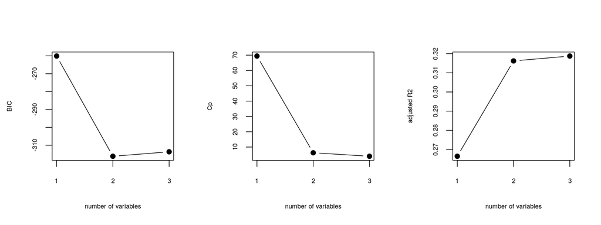

```r
par(mfrow=c(1,3),lab=c(2,5,3),pch=19)
plot(1:3,b$bic,type="b",xlab="number of variables",
     ylab="BIC")
plot(1:3,b$cp,type="b",xlab="number of variables",
     ylab="Cp")
plot(1:3,b$adjr2,type="b",xlab="number of variables",
     ylab="adjusted R2")
```

- As you can see, BIC chooses the 2 predictor model, while C$_p$ and adj. R$^2$ choose the 3 predictor model. As mentioned before, BIC penalizes the number of variables more than other criterion and generally tends to select simpler models.